# Prediccion de diversas cripto monedas

## Introduccion

Para este trabajo prediciremos BTC. Para lo anterior se utilizara Arima con Rolling, Sarima y VAR (con metodos de machine learning) y con las criptomonedas (Ethereum, BNB, Solana y XRP). Importamos las librerias principales y los datos desde yahoo finance.

## Modelos machine learning con **VAR**

El Modelo **VAR** signfica vector autoregression y tiene dos supuestos: estacionaridad y ser 2 o mas series de tiempo.

```python
import numpy as np
import pandas as pd
import seaborn as sns
import matplotlib
import matplotlib.ticker as ticker
import matplotlib.pyplot as plt
from scalecast.Forecaster import Forecaster
from scalecast.MVForecaster import MVForecaster
from scalecast.multiseries import export_model_summaries
from scalecast import GridGenerator
import yfinance as yf
import warnings
warnings.filterwarnings("ignore")
import warnings

def fxn():
    warnings.warn("deprecated", DeprecationWarning)

with warnings.catch_warnings():
    warnings.simplefilter("ignore")
    fxn()

# Or if you are using > Python 3.11:
with warnings.catch_warnings(action="ignore"):
    fxn()

sns.set_theme(style="whitegrid", palette="husl")
```

```python
ETH = yf.Ticker("ETH-USD")
BNB = yf.Ticker("BNB-USD")
SOL = yf.Ticker("SOL-USD")
BTC = yf.Ticker("BTC-USD")
XRP = yf.Ticker("XRP-USD")
```

```python
from yahoo_fin.stock_info import get_data
from datetime import datetime, timedelta
stock = 'ETH-USD'
resolution = '1d'
end_date = datetime.now()
start_date = end_date - timedelta(days=800)

def date_format(date_h):
    return date_h.strftime('%d/%m/%Y')

ETH_USD_df = get_data(stock, start_date=start_date, end_date=end_date, interval=resolution, index_as_date=False)
ETH_USD_df['date'] = pd.to_datetime(ETH_USD_df['date'], '%Y-%m-%d')
ETH_USD_df.index = ETH_USD_df['date']
ETH_USD_df.head()
```

| date | date | open | high | low | close | adjclose | volume | ticker |
| --- | --- | --- | --- | --- | --- | --- | --- | --- |
| 2022-04-02 | 2022-04-02 | 3449.788574 | 3521.284668 | 3442.000244 | 3445.059326 | 3445.059326 | 23571556215 | ETH-USD |
| 2022-04-03 | 2022-04-03 | 3444.810547 | 3573.960205 | 3421.259766 | 3522.833496 | 3522.833496 | 15333808649 | ETH-USD |
| 2022-04-04 | 2022-04-04 | 3522.364990 | 3535.148193 | 3422.000977 | 3521.241211 | 3521.241211 | 18209969743 | ETH-USD |
| 2022-04-05 | 2022-04-05 | 3521.239746 | 3546.706787 | 3410.547607 | 3411.792480 | 3411.792480 | 16681503199 | ETH-USD |
| 2022-04-06 | 2022-04-06 | 3411.672119 | 3411.672119 | 3171.205078 | 3171.691895 | 3171.691895 | 25632563639 | ETH-USD |

```python
stock = 'BNB-USD'
BNB_USD_df = get_data(stock, start_date=start_date, end_date=end_date, interval=resolution, index_as_date=False)
BNB_USD_df['date'] = pd.to_datetime(BNB_USD_df['date'], '%Y-%m-%d')
BNB_USD_df.index = BNB_USD_df['date']
BNB_USD_df.head()
```

| date | date | open | high | low | close | adjclose | volume | ticker |
| --- | --- | --- | --- | --- | --- | --- | --- | --- |
| 2022-04-02 | 2022-04-02 | 446.844208 | 453.558472 | 436.776703 | 436.955353 | 436.955353 | 2272901729 | BNB-USD |
| 2022-04-03 | 2022-04-03 | 436.865814 | 455.228455 | 432.821716 | 450.348877 | 450.348877 | 2128734028 | BNB-USD |
| 2022-04-04 | 2022-04-04 | 450.264557 | 450.432617 | 434.178009 | 447.524933 | 447.524933 | 2248856403 | BNB-USD |
| 2022-04-05 | 2022-04-05 | 447.630035 | 459.805573 | 445.038605 | 445.172607 | 445.172607 | 2268650039 | BNB-USD |
| 2022-04-06 | 2022-04-06 | 445.001129 | 445.027649 | 418.881134 | 420.146362 | 420.146362 | 2323241738 | BNB-USD |

```python
stock = 'SOL-USD'
SOL_USD_df = get_data(stock, start_date=start_date, end_date=end_date, interval=resolution, index_as_date=False)
SOL_USD_df['date'] = pd.to_datetime(SOL_USD_df['date'], '%Y-%m-%d')
SOL_USD_df.index = SOL_USD_df['date']
SOL_USD_df.head()
```

| date | date | open | high | low | close | adjclose | volume | ticker |
| --- | --- | --- | --- | --- | --- | --- | --- | --- |
| 2022-04-02 | 2022-04-02 | 134.453583 | 143.020020 | 132.139191 | 132.198868 | 132.198868 | 3394186456 | SOL-USD |
| 2022-04-03 | 2022-04-03 | 132.241074 | 140.263702 | 131.226151 | 136.775330 | 136.775330 | 2585967812 | SOL-USD |
| 2022-04-04 | 2022-04-04 | 136.760788 | 137.633514 | 126.865326 | 132.412628 | 132.412628 | 2828117206 | SOL-USD |
| 2022-04-05 | 2022-04-05 | 132.387863 | 136.182846 | 126.563972 | 126.862236 | 126.862236 | 2239922210 | SOL-USD |
| 2022-04-06 | 2022-04-06 | 126.857956 | 127.281158 | 112.773682 | 112.883385 | 112.883385 | 3281009143 | SOL-USD |

```python
stock = 'BTC-USD'
BTC_USD_df = get_data(stock, start_date=start_date, end_date=end_date, interval=resolution, index_as_date=False)
BTC_USD_df['date'] = pd.to_datetime(BTC_USD_df['date'], '%Y-%m-%d')
BTC_USD_df.index = BTC_USD_df['date']
BTC_USD_df.head()
```

| date | date | open | high | low | close | adjclose | volume | ticker |
| --- | --- | --- | --- | --- | --- | --- | --- | --- |
| 2022-04-02 | 2022-04-02 | 46285.500000 | 47028.281250 | 45782.511719 | 45868.949219 | 45868.949219 | 29336594194 | BTC-USD |
| 2022-04-03 | 2022-04-03 | 45859.128906 | 47313.476562 | 45634.105469 | 46453.566406 | 46453.566406 | 25414397610 | BTC-USD |
| 2022-04-04 | 2022-04-04 | 46445.273438 | 46791.089844 | 45235.816406 | 46622.675781 | 46622.675781 | 32499785455 | BTC-USD |
| 2022-04-05 | 2022-04-05 | 46624.507812 | 47106.140625 | 45544.808594 | 45555.992188 | 45555.992188 | 29640604055 | BTC-USD |
| 2022-04-06 | 2022-04-06 | 45544.355469 | 45544.355469 | 43193.953125 | 43206.738281 | 43206.738281 | 39393395788 | BTC-USD |

```python
stock = 'XRP-USD'
XRP_USD_df = get_data(stock, start_date=start_date, end_date=end_date, interval=resolution, index_as_date=False)
XRP_USD_df['date'] = pd.to_datetime(XRP_USD_df['date'], '%Y-%m-%d')
XRP_USD_df.index = XRP_USD_df['date']
XRP_USD_df.head()
```

| date | date | open | high | low | close | adjclose | volume | ticker |
| --- | --- | --- | --- | --- | --- | --- | --- | --- |
| 2022-04-02 | 2022-04-02 | 0.827735 | 0.848600 | 0.824828 | 0.824919 | 0.824919 | 1624227101 | XRP-USD |
| 2022-04-03 | 2022-04-03 | 0.824891 | 0.850154 | 0.817265 | 0.842950 | 0.842950 | 1348476817 | XRP-USD |
| 2022-04-04 | 2022-04-04 | 0.842923 | 0.842952 | 0.810890 | 0.827251 | 0.827251 | 1876069127 | XRP-USD |
| 2022-04-05 | 2022-04-05 | 0.827227 | 0.833287 | 0.817110 | 0.817642 | 0.817642 | 1548706718 | XRP-USD |
| 2022-04-06 | 2022-04-06 | 0.817627 | 0.818405 | 0.761285 | 0.761314 | 0.761314 | 2527126540 | XRP-USD |

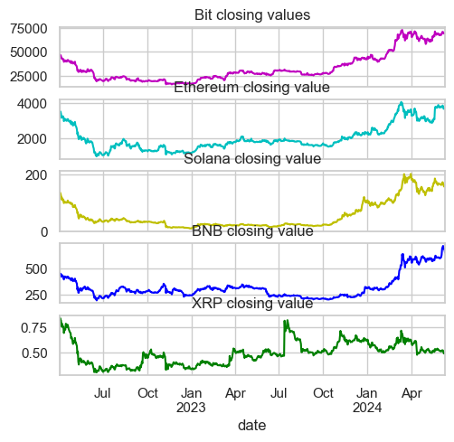

```python
fig, ax= plt.subplots(5, sharex=True)
fig.set_size_inches(5.5, 5,5)
BTC_USD_df['close'].plot(ax=ax[0], color='m')
ax[0].set_title('Bit closing values');

ETH_USD_df["close"].plot(ax=ax[1], color='c')
ax[1].set_title('Ethereum closing value');

SOL_USD_df["close"].plot(ax=ax[2], color='y')
ax[2].set_title('Solana closing value');

BNB_USD_df["close"].plot(ax=ax[3], color='b')
ax[3].set_title('BNB closing value');

XRP_USD_df["close"].plot(ax=ax[4], color='g')
ax[4].set_title('XRP closing value');

plt.show()
```

Con el grafico anterior podemos observar como varia nuestras series de tiempo. Observamos que todas las series de tiempo exepto **XRP** tienen una tendencia al la subida.

Revisamos prueba dicker fuller para comporbar la estacionaridad de nuestras series de tiempo. La hipotesis nula es que nuestra serie de tiempo no es estacionaria mientras que nuestra hipotesis alternativa es que nuestra serie de tiempo es estacionaria. Haremos esta prueba con una significacia de 0.05.

```python
from statsmodels.tsa.stattools import adfuller
from numpy import log

result = adfuller(BTC_USD_df.close)
print('ADF Statistic: %f' % result[0])
print('p-value: %f' % result[1])
```

```
ADF Statistic: 0.479493
p-value: 0.984236
```

La prueba de nuestra serie de tiempo **BTC** tiene un p-valor de 0.98 que es mayor que nuestra significacia de 0.05 por lo que no podemos rechazar nuestra hipotesis nula. Por lo que **BTC** no es estacionaria lo que es un requisito del modelo de VAR (Vector autoregression). Revisamos la cuatro series de tiempo restante para aplicarle differenciacion a las que no lo sean.

```python
result = adfuller(ETH_USD_df.close)
print('ADF Statistic: %f' % result[0])
print('p-value: %f' % result[1])
```

```
ADF Statistic: -1.263254
p-value: 0.645811
```

```python
result = adfuller(BNB_USD_df.close)
print('ADF Statistic: %f' % result[0])
print('p-value: %f' % result[1])
```

```
ADF Statistic: 0.144328
p-value: 0.968960
```

```python
result = adfuller(SOL_USD_df.close)
print('ADF Statistic: %f' % result[0])
print('p-value: %f' % result[1])
```

```
ADF Statistic: -0.587875
p-value: 0.873698
```

Nuestra serie de tiempo **SOL** tiene un p-valor 0.9 que es mayor que nuestra significacia de 0.05 por lo que no podemos rechazar nuestra hipotesis nula. Por lo que nuestra serie no es estacionaria.

```python
result = adfuller(XRP_USD_df.close)
print('ADF Statistic: %f' % result[0])
print('p-value: %f' % result[1])
```

```
ADF Statistic: -3.393567
p-value: 0.011180
```

Nuestra serie de tiempo **XRP** tiene un p-valor 0.01 que es menor que nuestra significacia de 0.05 por lo que podemos rechazar nuestra hipotesis nula. Por lo que nuestra serie es estacionaria. Dado que solo **XRP** de nuestras series de tiempo es estacionaria por lo que vamos a utilizar el metodo de diferenciacion para convertirlas en estacionarias.

```python
BTC_USD_df["diff"]=BTC_USD_df.close.diff()
BTC_USD_df=BTC_USD_df.dropna()
result = adfuller(BTC_USD_df["diff"])
print('ADF Statistic: %f' % result[0])
print('p-value: %f' % result[1])
```

```
ADF Statistic: -6.108577
p-value: 0.000000
```

Nuestra serie de tiempo **BTC** con una differenciacion de primer orden tiene un p-valor 0.000 que es menor que nuestra significacia de 0.05 por lo que podemos rechazar nuestra hipotesis nula. Por lo que nuestra serie es estacionaria.

```python
ETH_USD_df["diff"]=ETH_USD_df.close.diff()
ETH_USD_df=ETH_USD_df.dropna()
result = adfuller(ETH_USD_df["diff"])
print('ADF Statistic: %f' % result[0])
print('p-value: %f' % result[1])
```

```
ADF Statistic: -14.926001
p-value: 0.000000
```

Nuestra serie de tiempo **ETH** con una differenciacion de primer orden tiene un p-valor 0.000 que es menor que nuestra significacia de 0.05 por lo que podemos rechazar nuestra hipotesis nula. Por lo que nuestra serie es estacionaria.

```python
BNB_USD_df["diff"]=BNB_USD_df.close.diff()
BNB_USD_df=BNB_USD_df.dropna()
result = adfuller(BNB_USD_df["diff"])
print('ADF Statistic: %f' % result[0])
print('p-value: %f' % result[1])
```

```
ADF Statistic: -5.915794
p-value: 0.000000
```

Nuestra serie de tiempo **BNB** con una differenciacion de primer orden tiene un p-valor 0.000 que es menor que nuestra significacia de 0.05 por lo que podemos rechazar nuestra hipotesis nula. Por lo que nuestra serie es estacionaria.

```python
SOL_USD_df["diff"]=SOL_USD_df.close.diff()
SOL_USD_df=SOL_USD_df.dropna()
result = adfuller(SOL_USD_df["diff"])
print('ADF Statistic: %f' % result[0])
print('p-value: %f' % result[1])
```

```
ADF Statistic: -5.525689
p-value: 0.000002
```

Nuestra serie de tiempo **SOL** con una differenciacion de primer orden tiene un p-valor 0.000 que es menor que nuestra significacia de 0.05 por lo que podemos rechazar nuestra hipotesis nula. Por lo que nuestra serie es estacionaria.

Procedemos a descargar los modelos a revisar y convertimos nuestros datos en *Forecaster* para facilitar la predicion.

```python
models = ('mlr','elasticnet','knn','gbt','xgboost','mlp')
GridGenerator.get_example_grids()
GridGenerator.get_mv_grids()
fBTC = Forecaster(
    y=BTC_USD_df['diff'],
    current_dates = BTC_USD_df['date'],
    test_length = .2,
    future_dates = 52,
    validation_length = 4,
    metrics = ["rmse","r2","mape"],
    cis = True,
)
fBNB = Forecaster(
    y=BNB_USD_df['diff'],
    current_dates = BNB_USD_df['date'],
    test_length = .2,
    future_dates = 52,
    validation_length = 4,
    metrics = ["rmse","r2","mape"],
    cis = True,
)
fSOL = Forecaster(
    y=SOL_USD_df['diff'],
    current_dates = SOL_USD_df['date'],
    test_length = .2,
    future_dates = 52,
    validation_length = 4,
    metrics = ["rmse","r2","mape"],
    cis = True,
)
fETH = Forecaster(
    y=ETH_USD_df['diff'],
    current_dates = ETH_USD_df['date'],
    test_length = .2,
    future_dates = 52,
    validation_length = 4,
    metrics = ["rmse","r2","mape"],
    cis = True,
)
fXRP = Forecaster(
    y=XRP_USD_df['close'],
    current_dates = XRP_USD_df['date'],
    test_length = .2,
    future_dates = 52,
    validation_length = 4,
    metrics = ["rmse","r2","mape"],
    cis = True,
)
```

```python
for f in (fBTC,fBNB,fSOL,fXRP, fETH ):
    f.auto_Xvar_select(
        estimator = 'elasticnet',
        monitor = 'ValidationMetricValue',
        irr_cycles = [4],
        cross_validate=True,
        cvkwargs={
            'k':3,
            'test_length':13,
            'space_between_sets':4,
        }
    )
```

Empezamos a programar nuestro modelos para cada una de nuestras cryptomonedas y graficamos las prediccion de los modelos de machine learning para cada una de las criptomoneda

[output not shown]

[output cut: 82 more lines]

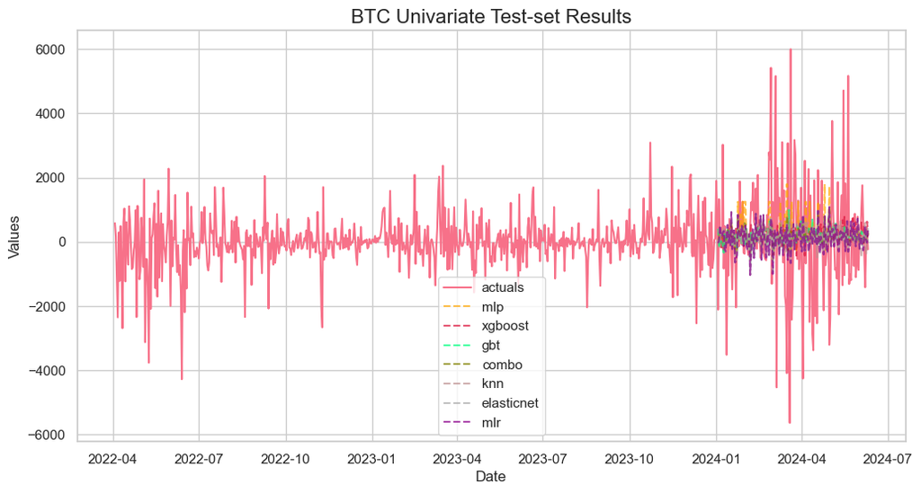

```python
fBTC.tune_test_forecast(models,feature_importance=True)
best_model_con_uni = fBTC.order_fcsts()[0]
fBTC.set_estimator('combo')
fBTC.manual_forecast(how='weighted')
fBTC.plot_test_set(order_by='TestSetMAPE')
plt.title('BTC Univariate Test-set Results',size=16)
plt.show()
```

[output not shown]

[output cut: 74 more lines]

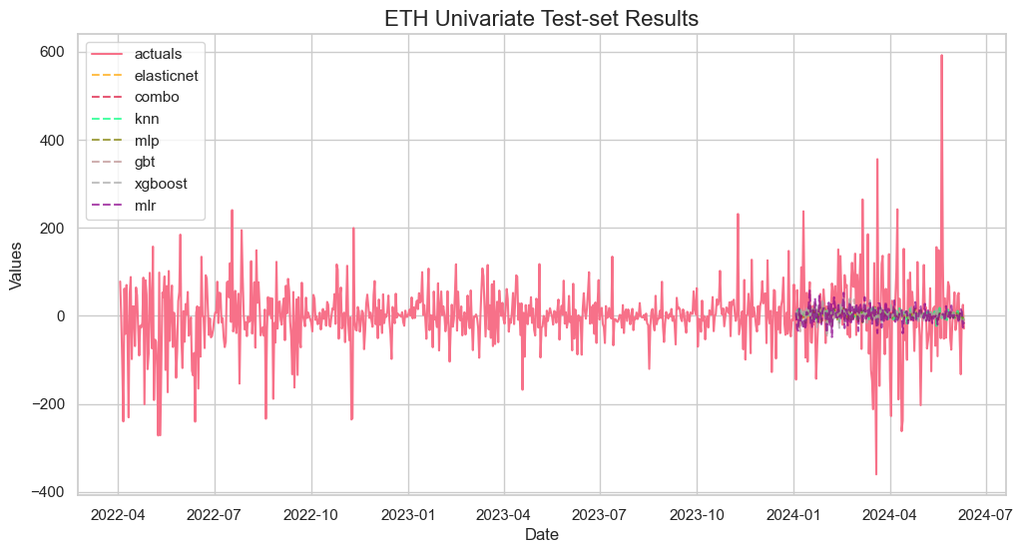

```python
fETH.tune_test_forecast(models,feature_importance=True)
best_model_con_uni = fETH.order_fcsts()[0]
fETH.set_estimator('combo')
fETH.manual_forecast(how='weighted')
fETH.plot_test_set(order_by='TestSetMAPE')
plt.title('ETH Univariate Test-set Results',size=16)
plt.show()
```

[output not shown]

[output cut: 69 more lines]

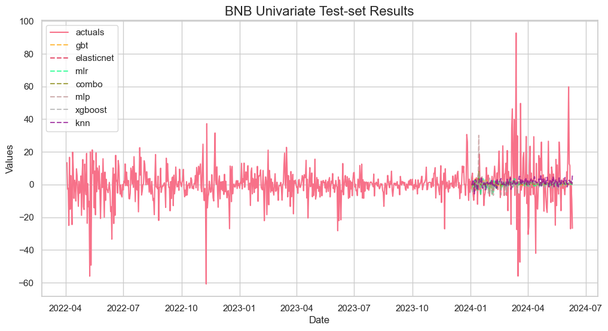

```python
fBNB.tune_test_forecast(models,feature_importance=True)
best_model_con_uni = fBNB.order_fcsts()[0]
fBNB.set_estimator('combo')
fBNB.manual_forecast(how='weighted')
fBNB.plot_test_set(order_by='TestSetMAPE')
plt.title('BNB Univariate Test-set Results',size=16)
plt.show()
```

[output not shown]

[output cut: 65 more lines]

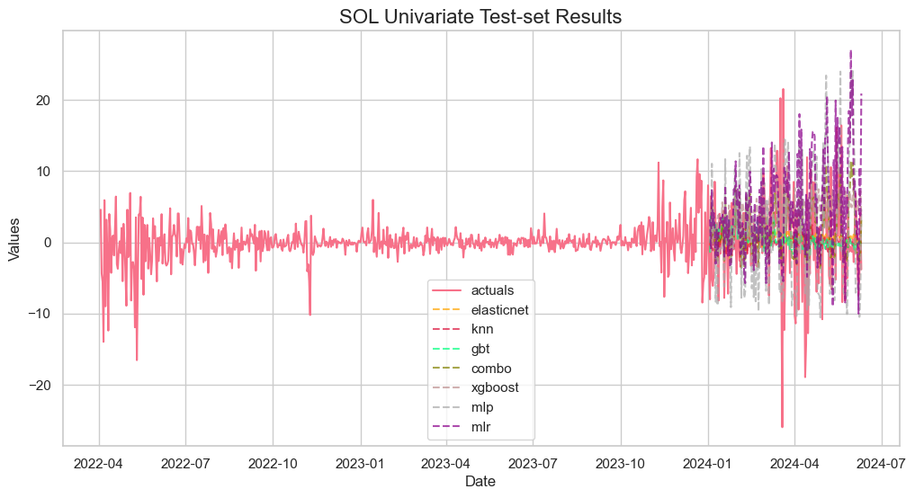

```python
fSOL.tune_test_forecast(models,feature_importance=True)
best_model_con_uni = fSOL.order_fcsts()[0]
fSOL.set_estimator('combo')
fSOL.manual_forecast(how='weighted')
fSOL.plot_test_set(order_by='TestSetMAPE')
plt.title('SOL Univariate Test-set Results',size=16)
plt.show()
```

[output not shown]

[output cut: 46 more lines]

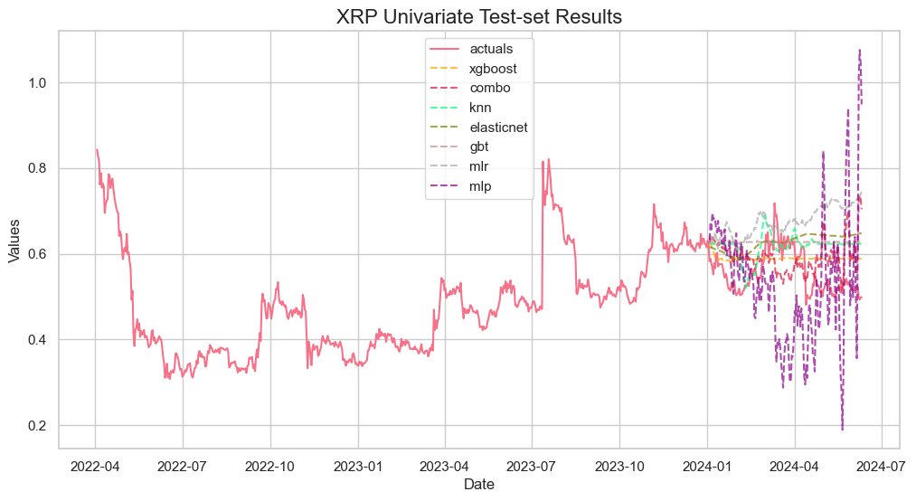

```python
fXRP.tune_test_forecast(models,feature_importance=True)
best_model_con_uni = fXRP.order_fcsts()[0]
fXRP.set_estimator('combo')
fXRP.manual_forecast(how='weighted')
fXRP.plot_test_set(order_by='TestSetMAPE')
plt.title('XRP Univariate Test-set Results',size=16)
plt.show()
```

```python
pd.set_option('display.float_format',  '{:.4f}'.format)
ms = export_model_summaries({'BTC':fBTC,'BNB':fBNB,'SOL':fSOL,'ETH':fETH,
                             'XRP':fXRP}, determine_best_by='InSampleMAPE')

ms[
    [
        'ModelNickname',
        'Series',
        'TestSetMAPE',
        'TestSetR2',
        'InSampleMAPE',
        'InSampleR2',
        'best_model'
    ]
]
```

|  | ModelNickname | Series | TestSetMAPE | TestSetR2 | InSampleMAPE | InSampleR2 | best_model |
| --- | --- | --- | --- | --- | --- | --- | --- |
| 0 | xgboost | BTC | 2.1168 | -0.0520 | 0.1251 | 0.9999 | True |
| 1 | gbt | BTC | 2.2026 | -0.0278 | 1.1011 | 0.9712 | False |
| 2 | mlp | BTC | 2.1054 | -0.1295 | 1.9266 | 0.1996 | False |
| 3 | knn | BTC | 3.1418 | -0.0345 | 4.8149 | 0.1894 | False |
| 4 | combo | BTC | 2.8692 | -0.0710 | 6.7062 | 0.5046 | False |
| 5 | elasticnet | BTC | 3.5334 | -0.1026 | 13.9628 | 0.3116 | False |
| 6 | mlr | BTC | 3.5840 | -0.1032 | 14.0001 | 0.3116 | False |
| 7 | xgboost | BNB | 1.3817 | -0.0204 | 0.3634 | 0.9967 | True |
| 8 | gbt | BNB | 1.0711 | -0.0188 | 1.5258 | 0.9025 | False |
| 9 | combo | BNB | 1.3247 | -0.0084 | 1.5913 | 0.5521 | False |
| 10 | elasticnet | BNB | 1.0595 | -0.0106 | 1.6992 | 0.0561 | False |
| 11 | knn | BNB | 1.6870 | -0.0268 | 2.2015 | 0.2367 | False |
| 12 | mlp | BNB | 1.8648 | -0.0281 | 2.3053 | 0.4732 | False |
| 13 | mlr | BNB | 1.0865 | -0.0033 | 3.1397 | 0.1445 | False |
| 14 | xgboost | SOL | 3.5932 | -0.4013 | 0.0015 | 1.0000 | True |
| 15 | mlp | SOL | 10.3769 | -9.4961 | 0.0075 | 1.0000 | False |
| 16 | gbt | SOL | 1.6680 | -0.0214 | 0.7400 | 0.9938 | False |
| 17 | combo | SOL | 5.1635 | -1.5887 | 1.1827 | 0.9499 | False |
| 18 | knn | SOL | 1.7511 | -0.0268 | 2.4119 | 0.7258 | False |
| 19 | elasticnet | SOL | 1.6695 | -0.0008 | 4.7052 | 0.4071 | False |
| 20 | mlr | SOL | 5.6708 | -1.3533 | 6.5100 | 0.5133 | False |
| 21 | xgboost | ETH | 1.7185 | -0.0297 | 0.0739 | 0.9998 | True |
| 22 | gbt | ETH | 1.4942 | -0.0216 | 0.8771 | 0.9287 | False |
| 23 | combo | ETH | 1.3014 | -0.0259 | 1.3231 | 0.5896 | False |
| 24 | elasticnet | ETH | 1.1185 | -0.0115 | 1.6016 | 0.0825 | False |
| 25 | knn | ETH | 1.3820 | -0.0342 | 1.7368 | 0.0753 | False |
| 26 | mlp | ETH | 1.7820 | -0.0631 | 2.5136 | 0.3451 | False |
| 27 | mlr | ETH | 2.1794 | -0.0546 | 3.2178 | 0.2542 | False |
| 28 | xgboost | XRP | 0.0817 | -0.1250 | 0.0016 | 0.9999 | True |
| 29 | gbt | XRP | 0.1410 | -2.1160 | 0.0125 | 0.9915 | False |
| 30 | combo | XRP | 0.1090 | -0.9380 | 0.0141 | 0.9875 | False |
| 31 | knn | XRP | 0.1281 | -1.7168 | 0.0159 | 0.9729 | False |
| 32 | mlp | XRP | 0.0877 | -0.4554 | 0.0218 | 0.9707 | False |
| 33 | mlr | XRP | 0.2288 | -7.1827 | 0.0232 | 0.9565 | False |
| 34 | elasticnet | XRP | 0.1403 | -2.2678 | 0.0641 | 0.7749 | False |

```python
mvf = MVForecaster(
    fBTC,fBNB,fSOL, fXRP,fETH,
    names=['BTC','BNB',"SOL","XRP","ETH"],
    test_length = .2,
    valiation_length = 4,
    cis = True,
    metrics = ['rmse','mape','mae','r2'],
) # init the mvf object
mvf
```

```
MVForecaster(
    DateStartActuals=2022-04-03T00:00:00.000000000
    DateEndActuals=2024-06-10T00:00:00.000000000
    Freq=D
    N_actuals=800
    N_series=5
    SeriesNames=['BTC', 'BNB', 'SOL', 'XRP', 'ETH']
    ForecastLength=52
    Xvars=['t', 'dayofyearsin', 'dayofyearcos', 'daysin', 'daycos', 'dayofweeksin', 'dayofweekcos', 'cycle4sin', 'cycle4cos']
    TestLength=160
    ValidationLength=1
    ValidationMetric=rmse
    ForecastsEvaluated=[]
    CILevel=0.95
    CurrentEstimator=mlr
    OptimizeOn=mean
    GridsFile=MVGrids
)
```

```python
# how to optimize on one series
mvf.set_optimize_on('BTC')
# how to optimize using a weighted avarage
mvf.add_optimizer_func(lambda x: x[0]*.25 + x[1]*.75,'weighted')
mvf.set_optimize_on('weighted')
# how to optimize on the average of both/all series (default)
mvf.set_optimize_on('mean')
```

```python
mvf.tune_test_forecast(models)
mvf.set_best_model(determine_best_by='TestSetMAPE')
```

[output not shown]

[output cut: 1532 more lines]

```python
results = mvf.export('model_summaries')
results
```

|  | Series | ModelNickname | Estimator | Xvars | HyperParams | Lags | Observations | DynamicallyTested | TestSetLength | ValidationMetric | ... | MetricOptimized | best_model | InSampleRMSE | InSampleMAPE | InSampleMAE | InSampleR2 | TestSetRMSE | TestSetMAPE | TestSetMAE | TestSetR2 |
| --- | --- | --- | --- | --- | --- | --- | --- | --- | --- | --- | --- | --- | --- | --- | --- | --- | --- | --- | --- | --- | --- |
| 0 | BTC | mlr | mlr | [t, dayofyearsin, dayofyearcos, daysin, daycos... | {'normalizer': None} | 3 | 800 | True | 160 | rmse | ... | TestSetMAPE | True | 1008.1175 | 4.4163 | 648.2776 | 0.0746 | 1797.2653 | 1.7452 | 1287.0785 | 0.0022 |
| 1 | BTC | elasticnet | elasticnet | [t, dayofyearsin, dayofyearcos, daysin, daycos... | {'alpha': 2.0, 'l1_ratio': 0, 'normalizer': None} | 1 | 800 | True | 160 | rmse | ... | TestSetMAPE | False | 1028.5030 | 3.6889 | 638.5436 | 0.0358 | 1800.7499 | 2.8248 | 1288.3093 | -0.0016 |
| 2 | BTC | knn | knn | [t, dayofyearsin, dayofyearcos, daysin, daycos... | {'n_neighbors': 6} | 1 | 800 | True | 160 | rmse | ... | TestSetMAPE | False | 902.1676 | 4.6965 | 605.3625 | 0.2581 | 1860.2307 | 1.7138 | 1320.0688 | -0.0689 |
| 3 | BTC | gbt | gbt | [t, dayofyearsin, dayofyearcos, daysin, daycos... | {'max_depth': 3, 'max_features': 'sqrt'} | 1 | 800 | True | 160 | rmse | ... | TestSetMAPE | False | 668.4468 | 3.1669 | 458.1026 | 0.5927 | 1854.2579 | 3.2935 | 1371.1482 | -0.0621 |
| 4 | BTC | xgboost | xgboost | [t, dayofyearsin, dayofyearcos, daysin, daycos... | {'n_estimators': 150, 'scale_pos_weight': 5, '... | 6 | 800 | True | 160 | rmse | ... | TestSetMAPE | False | 2.2333 | 0.0331 | 1.5989 | 1.0000 | 1801.4468 | 2.9648 | 1291.3114 | -0.0024 |
| 5 | BTC | mlp | mlp | [t, dayofyearsin, dayofyearcos, daysin, daycos... | {'activation': 'relu', 'hidden_layer_sizes': (... | 3 | 800 | True | 160 | rmse | ... | TestSetMAPE | False | 207.2677 | 2.9814 | 149.3929 | 0.9609 | 17820531158688.7422 | 26144092850.2958 | 3613615336437.3618 | -98095349801253224448.0000 |
| 6 | BTC | stacking | stacking | [t, dayofyearsin, dayofyearcos, daysin, daycos... | {'estimators': [('mlr', LinearRegression()), (... | 13 | 800 | True | 160 | NaN | ... | TestSetMAPE | False | 1071.6099 | 4.6528 | 686.7064 | -0.0548 | 1854.7360 | 3.1843 | 1346.5205 | -0.0626 |
| 7 | BNB | mlr | mlr | [t, dayofyearsin, dayofyearcos, daysin, daycos... | {'normalizer': None} | 3 | 800 | True | 160 | rmse | ... | TestSetMAPE | True | 10.7581 | 2.5782 | 6.8062 | 0.0588 | 17.3122 | 1.1010 | 11.2722 | -0.0164 |
| 8 | BNB | elasticnet | elasticnet | [t, dayofyearsin, dayofyearcos, daysin, daycos... | {'alpha': 2.0, 'l1_ratio': 0, 'normalizer': None} | 1 | 800 | True | 160 | rmse | ... | TestSetMAPE | False | 10.9162 | 2.0141 | 6.7217 | 0.0287 | 17.2209 | 1.2131 | 11.2747 | -0.0058 |
| 9 | BNB | knn | knn | [t, dayofyearsin, dayofyearcos, daysin, daycos... | {'n_neighbors': 6} | 1 | 800 | True | 160 | rmse | ... | TestSetMAPE | False | 9.7406 | 2.3439 | 6.5297 | 0.2266 | 17.6010 | 1.4932 | 11.7864 | -0.0506 |
| 10 | BNB | gbt | gbt | [t, dayofyearsin, dayofyearcos, daysin, daycos... | {'max_depth': 3, 'max_features': 'sqrt'} | 1 | 800 | True | 160 | rmse | ... | TestSetMAPE | False | 7.1630 | 2.1088 | 5.0259 | 0.5818 | 17.8413 | 2.4938 | 12.4662 | -0.0795 |
| 11 | BNB | xgboost | xgboost | [t, dayofyearsin, dayofyearcos, daysin, daycos... | {'n_estimators': 150, 'scale_pos_weight': 5, '... | 6 | 800 | True | 160 | rmse | ... | TestSetMAPE | False | 1.0676 | 0.4781 | 0.7947 | 0.9907 | 17.3456 | 2.3862 | 11.8395 | -0.0204 |
| 12 | BNB | mlp | mlp | [t, dayofyearsin, dayofyearcos, daysin, daycos... | {'activation': 'relu', 'hidden_layer_sizes': (... | 3 | 800 | True | 160 | rmse | ... | TestSetMAPE | False | 2.2352 | 1.9285 | 1.4871 | 0.9594 | 563739618197.4526 | 30782891415.9790 | 110009754850.9238 | -1077798981964700188672.0000 |
| 13 | BNB | stacking | stacking | [t, dayofyearsin, dayofyearcos, daysin, daycos... | {'estimators': [('mlr', LinearRegression()), (... | 13 | 800 | True | 160 | NaN | ... | TestSetMAPE | False | 11.3443 | 3.4027 | 7.4574 | -0.0595 | 17.7806 | 2.2196 | 11.9899 | -0.0722 |
| 14 | SOL | mlr | mlr | [t, dayofyearsin, dayofyearcos, daysin, daycos... | {'normalizer': None} | 3 | 800 | True | 160 | rmse | ... | TestSetMAPE | True | 3.4802 | 3.4084 | 2.1745 | 0.1185 | 6.6062 | 1.1727 | 4.8724 | -0.0005 |
| 15 | SOL | elasticnet | elasticnet | [t, dayofyearsin, dayofyearcos, daysin, daycos... | {'alpha': 2.0, 'l1_ratio': 0, 'normalizer': None} | 1 | 800 | True | 160 | rmse | ... | TestSetMAPE | False | 3.6198 | 2.4048 | 2.1510 | 0.0484 | 6.6311 | 1.3340 | 4.8969 | -0.0080 |
| 16 | SOL | knn | knn | [t, dayofyearsin, dayofyearcos, daysin, daycos... | {'n_neighbors': 6} | 1 | 800 | True | 160 | rmse | ... | TestSetMAPE | False | 3.2377 | 5.1961 | 2.0789 | 0.2386 | 6.7514 | 1.2547 | 4.9265 | -0.0450 |
| 17 | SOL | gbt | gbt | [t, dayofyearsin, dayofyearcos, daysin, daycos... | {'max_depth': 3, 'max_features': 'sqrt'} | 1 | 800 | True | 160 | rmse | ... | TestSetMAPE | False | 2.2620 | 1.9201 | 1.4977 | 0.6284 | 6.9633 | 2.5382 | 5.3348 | -0.1116 |
| 18 | SOL | xgboost | xgboost | [t, dayofyearsin, dayofyearcos, daysin, daycos... | {'n_estimators': 150, 'scale_pos_weight': 5, '... | 6 | 800 | True | 160 | rmse | ... | TestSetMAPE | False | 0.8571 | 1.4789 | 0.6511 | 0.9452 | 7.0810 | 2.5292 | 5.3737 | -0.1495 |
| 19 | SOL | mlp | mlp | [t, dayofyearsin, dayofyearcos, daysin, daycos... | {'activation': 'relu', 'hidden_layer_sizes': (... | 3 | 800 | True | 160 | rmse | ... | TestSetMAPE | False | 0.5126 | 2.2476 | 0.3505 | 0.9809 | 150831531561.0858 | 11000425071.6537 | 29409930117.4480 | -521544828110414544896.0000 |
| 20 | SOL | stacking | stacking | [t, dayofyearsin, dayofyearcos, daysin, daycos... | {'estimators': [('mlr', LinearRegression()), (... | 13 | 800 | True | 160 | NaN | ... | TestSetMAPE | False | 3.6820 | 4.6180 | 2.2880 | -0.0226 | 6.5697 | 1.0431 | 4.7607 | 0.0105 |
| 21 | XRP | mlr | mlr | [t, dayofyearsin, dayofyearcos, daysin, daycos... | {'normalizer': None} | 3 | 800 | True | 160 | rmse | ... | TestSetMAPE | True | 0.0210 | 0.0243 | 0.0120 | 0.9634 | 0.1138 | 0.1824 | 0.0966 | -4.6073 |
| 22 | XRP | elasticnet | elasticnet | [t, dayofyearsin, dayofyearcos, daysin, daycos... | {'alpha': 2.0, 'l1_ratio': 0, 'normalizer': None} | 1 | 800 | True | 160 | rmse | ... | TestSetMAPE | False | 0.0964 | 0.1432 | 0.0702 | 0.2453 | 0.0656 | 0.1032 | 0.0553 | -0.8599 |
| 23 | XRP | knn | knn | [t, dayofyearsin, dayofyearcos, daysin, daycos... | {'n_neighbors': 6} | 1 | 800 | True | 160 | rmse | ... | TestSetMAPE | False | 0.0721 | 0.1161 | 0.0562 | 0.5781 | 0.0993 | 0.1297 | 0.0764 | -3.2659 |
| 24 | XRP | gbt | gbt | [t, dayofyearsin, dayofyearcos, daysin, daycos... | {'max_depth': 3, 'max_features': 'sqrt'} | 1 | 800 | True | 160 | rmse | ... | TestSetMAPE | False | 0.0145 | 0.0215 | 0.0103 | 0.9830 | 0.0786 | 0.1253 | 0.0668 | -1.6705 |
| 25 | XRP | xgboost | xgboost | [t, dayofyearsin, dayofyearcos, daysin, daycos... | {'n_estimators': 150, 'scale_pos_weight': 5, '... | 6 | 800 | True | 160 | rmse | ... | TestSetMAPE | False | 0.0953 | 0.1580 | 0.0741 | 0.2321 | 0.1025 | 0.1569 | 0.0905 | -3.5438 |
| 26 | XRP | mlp | mlp | [t, dayofyearsin, dayofyearcos, daysin, daycos... | {'activation': 'relu', 'hidden_layer_sizes': (... | 3 | 800 | True | 160 | rmse | ... | TestSetMAPE | False | 0.0178 | 0.0241 | 0.0118 | 0.9737 | 896649342.1326 | 338646295.0031 | 170532170.9931 | -347954314211152822272.0000 |
| 27 | XRP | stacking | stacking | [t, dayofyearsin, dayofyearcos, daysin, daycos... | {'estimators': [('mlr', LinearRegression()), (... | 13 | 800 | True | 160 | NaN | ... | TestSetMAPE | False | 0.0226 | 0.0293 | 0.0141 | 0.9549 | 0.0903 | 0.1506 | 0.0799 | -2.5315 |
| 28 | ETH | mlr | mlr | [t, dayofyearsin, dayofyearcos, daysin, daycos... | {'normalizer': None} | 3 | 800 | True | 160 | rmse | ... | TestSetMAPE | True | 69.8168 | 3.5893 | 46.9282 | 0.0806 | 108.4105 | 1.4363 | 74.5254 | -0.0063 |
| 29 | ETH | elasticnet | elasticnet | [t, dayofyearsin, dayofyearcos, daysin, daycos... | {'alpha': 2.0, 'l1_ratio': 0, 'normalizer': None} | 1 | 800 | True | 160 | rmse | ... | TestSetMAPE | False | 71.7412 | 3.1912 | 46.8908 | 0.0296 | 108.1830 | 1.4911 | 74.2842 | -0.0021 |
| 30 | ETH | knn | knn | [t, dayofyearsin, dayofyearcos, daysin, daycos... | {'n_neighbors': 6} | 1 | 800 | True | 160 | rmse | ... | TestSetMAPE | False | 62.6349 | 7.3751 | 43.3188 | 0.2603 | 111.0377 | 1.5784 | 76.6218 | -0.0557 |
| 31 | ETH | gbt | gbt | [t, dayofyearsin, dayofyearcos, daysin, daycos... | {'max_depth': 3, 'max_features': 'sqrt'} | 1 | 800 | True | 160 | rmse | ... | TestSetMAPE | False | 49.8252 | 2.2917 | 35.0338 | 0.5319 | 108.8275 | 1.5626 | 74.5035 | -0.0141 |
| 32 | ETH | xgboost | xgboost | [t, dayofyearsin, dayofyearcos, daysin, daycos... | {'n_estimators': 150, 'scale_pos_weight': 5, '... | 6 | 800 | True | 160 | rmse | ... | TestSetMAPE | False | 1.0985 | 0.1167 | 0.8123 | 0.9998 | 111.2275 | 2.7500 | 76.0925 | -0.0593 |
| 33 | ETH | mlp | mlp | [t, dayofyearsin, dayofyearcos, daysin, daycos... | {'activation': 'relu', 'hidden_layer_sizes': (... | 3 | 800 | True | 160 | rmse | ... | TestSetMAPE | False | 18.1591 | 1.9051 | 13.4310 | 0.9378 | 2001494440939.7847 | 58639931956.8356 | 380915253902.8069 | -343008029481892773888.0000 |
| 34 | ETH | stacking | stacking | [t, dayofyearsin, dayofyearcos, daysin, daycos... | {'estimators': [('mlr', LinearRegression()), (... | 13 | 800 | True | 160 | NaN | ... | TestSetMAPE | False | 75.0699 | 3.7107 | 52.1441 | -0.0868 | 112.9650 | 2.0772 | 78.0257 | -0.0927 |

35 rows × 22 columns

procedemos a ensamblar el modelo

```python
from sklearn.ensemble import StackingRegressor
from sklearn.linear_model import LinearRegression
from sklearn.linear_model import ElasticNet
from sklearn.neural_network import MLPRegressor
from sklearn.neighbors import KNeighborsRegressor
from xgboost import XGBRegressor
estimators = [
    (
        'mlr',
        LinearRegression()
    ),
    (
        'elasticnet',
        ElasticNet(
            **{
                k:v for k,v in (
                    results.loc[
                        results['ModelNickname'] == 'elasticnet',
                        'HyperParams',
                    ].values[0]
                ).items() if k != 'normalizer'
              }
        )
    ),
    (
        'mlp',
        MLPRegressor(
            **{
                k:v for k,v in (
                    results.loc[
                        results['ModelNickname'] == 'mlp',
                        'HyperParams',
                    ].values[0]
                ).items() if k != 'normalizer'
              }
        )
    )
]

final_estimator = KNeighborsRegressor(
    **{
        k:v for k,v in (
            results.loc[
                results['ModelNickname'] == 'knn',
                'HyperParams',
            ].values[0]
        ).items() if k != 'normalizer'
      }
)
mvf.add_sklearn_estimator(StackingRegressor,'stacking')
mvf.set_estimator('stacking')
mvf.manual_forecast(estimators=estimators,final_estimator=final_estimator,lags=13)
```

[output not shown]

[output cut: 245 more lines]

[output not shown]

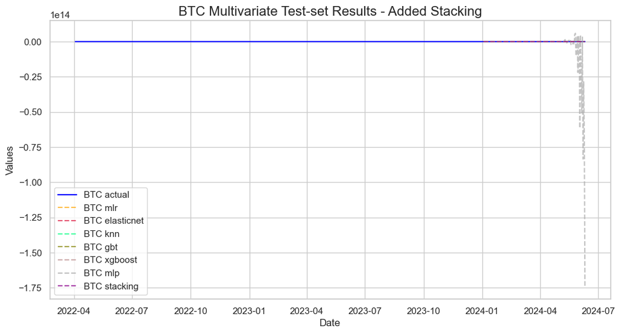

```python
mvf.plot_test_set(series='BTC',put_best_on_top=True)
plt.title('BTC Multivariate Test-set Results - Added Stacking',size=16)
plt.show()
```

```python
mvf.set_best_model(determine_best_by='TestSetRMSE')
results2 = mvf.export('model_summaries')
results2 = results2[
    [
        'ModelNickname',
        'Series',
        'TestSetRMSE',
        'TestSetR2',
        'InSampleRMSE',
        'InSampleR2',
        'Lags',
        'best_model'
    ]
]

results2
```

|  | ModelNickname | Series | TestSetRMSE | TestSetR2 | InSampleRMSE | InSampleR2 | Lags | best_model |
| --- | --- | --- | --- | --- | --- | --- | --- | --- |
| 0 | mlr | BTC | 1797.2653 | 0.0022 | 1008.1175 | 0.0746 | 3 | True |
| 1 | elasticnet | BTC | 1800.7499 | -0.0016 | 1028.5030 | 0.0358 | 1 | False |
| 2 | knn | BTC | 1860.2307 | -0.0689 | 902.1676 | 0.2581 | 1 | False |
| 3 | gbt | BTC | 1854.2579 | -0.0621 | 668.4468 | 0.5927 | 1 | False |
| 4 | xgboost | BTC | 1801.4468 | -0.0024 | 2.2333 | 1.0000 | 6 | False |
| 5 | mlp | BTC | 17820531158688.7422 | -98095349801253224448.0000 | 207.2677 | 0.9609 | 3 | False |
| 6 | stacking | BTC | 1843.4586 | -0.0497 | 1101.8699 | -0.1153 | 13 | False |
| 7 | mlr | BNB | 17.3122 | -0.0164 | 10.7581 | 0.0588 | 3 | True |
| 8 | elasticnet | BNB | 17.2209 | -0.0058 | 10.9162 | 0.0287 | 1 | False |
| 9 | knn | BNB | 17.6010 | -0.0506 | 9.7406 | 0.2266 | 1 | False |
| 10 | gbt | BNB | 17.8413 | -0.0795 | 7.1630 | 0.5818 | 1 | False |
| 11 | xgboost | BNB | 17.3456 | -0.0204 | 1.0676 | 0.9907 | 6 | False |
| 12 | mlp | BNB | 563739618197.4526 | -1077798981964700188672.0000 | 2.2352 | 0.9594 | 3 | False |
| 13 | stacking | BNB | 17.1813 | -0.0011 | 11.8723 | -0.1604 | 13 | False |
| 14 | mlr | SOL | 6.6062 | -0.0005 | 3.4802 | 0.1185 | 3 | True |
| 15 | elasticnet | SOL | 6.6311 | -0.0080 | 3.6198 | 0.0484 | 1 | False |
| 16 | knn | SOL | 6.7514 | -0.0450 | 3.2377 | 0.2386 | 1 | False |
| 17 | gbt | SOL | 6.9633 | -0.1116 | 2.2620 | 0.6284 | 1 | False |
| 18 | xgboost | SOL | 7.0810 | -0.1495 | 0.8571 | 0.9452 | 6 | False |
| 19 | mlp | SOL | 150831531561.0858 | -521544828110414544896.0000 | 0.5126 | 0.9809 | 3 | False |
| 20 | stacking | SOL | 6.6180 | -0.0041 | 3.5829 | 0.0317 | 13 | False |
| 21 | mlr | XRP | 0.1138 | -4.6073 | 0.0210 | 0.9634 | 3 | True |
| 22 | elasticnet | XRP | 0.0656 | -0.8599 | 0.0964 | 0.2453 | 1 | False |
| 23 | knn | XRP | 0.0993 | -3.2659 | 0.0721 | 0.5781 | 1 | False |
| 24 | gbt | XRP | 0.0786 | -1.6705 | 0.0145 | 0.9830 | 1 | False |
| 25 | xgboost | XRP | 0.1025 | -3.5438 | 0.0953 | 0.2321 | 6 | False |
| 26 | mlp | XRP | 896649342.1326 | -347954314211152822272.0000 | 0.0178 | 0.9737 | 3 | False |
| 27 | stacking | XRP | 0.0927 | -2.7224 | 0.0229 | 0.9539 | 13 | False |
| 28 | mlr | ETH | 108.4105 | -0.0063 | 69.8168 | 0.0806 | 3 | True |
| 29 | elasticnet | ETH | 108.1830 | -0.0021 | 71.7412 | 0.0296 | 1 | False |
| 30 | knn | ETH | 111.0377 | -0.0557 | 62.6349 | 0.2603 | 1 | False |
| 31 | gbt | ETH | 108.8275 | -0.0141 | 49.8252 | 0.5319 | 1 | False |
| 32 | xgboost | ETH | 111.2275 | -0.0593 | 1.0985 | 0.9998 | 6 | False |
| 33 | mlp | ETH | 2001494440939.7847 | -343008029481892773888.0000 | 18.1591 | 0.9378 | 3 | False |
| 34 | stacking | ETH | 109.1214 | -0.0196 | 76.2950 | -0.1225 | 13 | False |

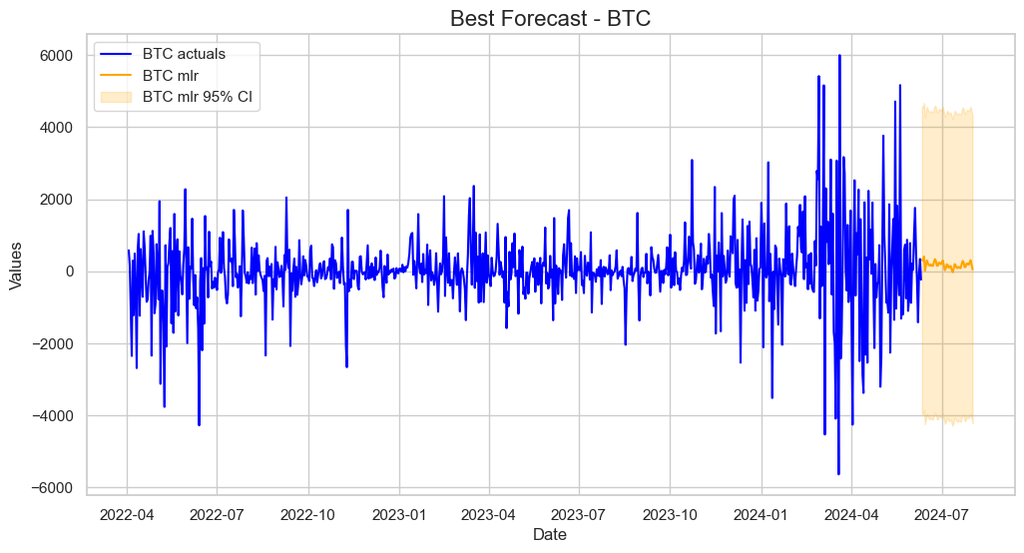

```python
best_model_con = (
    results2.loc[results2['Series'] == 'BTC']
    .sort_values("TestSetR2",ascending=False)
    .iloc[0,0]
)
mvf.plot(series='BTC',models=best_model_con,ci=True)
plt.title('Best Forecast - BTC',size=16)
plt.show()
```

## ARIMA

**A**uto**R**egresion **I**ntegrado convierte las series de tiempo en estacionarias. **M**oving **A**verage modela el error como combinacion lineal de errores anteriores.

**ARIMA(p, d, q)**

**p** numero de lag observados

**d** numero de differenciones

**q** tamaño de la ventana del moving averege

Buscamos el numero de lags en nuestras series de tiempo.

```python
# pmdarima Library
from pmdarima import ARIMA, auto_arima

# statsmodels Library
from statsmodels.tsa.statespace.sarimax import SARIMAX
from statsmodels.tsa.stattools import adfuller, kpss
from statsmodels.graphics.tsaplots import plot_acf, plot_pacf
from statsmodels.tsa.seasonal import seasonal_decompose

# skforecast Library
from skforecast.Sarimax import Sarimax
from skforecast.ForecasterSarimax import ForecasterSarimax
from skforecast.model_selection_sarimax import backtesting_sarimax, grid_search_sarimax
from sklearn.metrics import mean_absolute_error
```

```python
def plotds(xt, nlag=30, fig_size=(12, 10)):

    if not isinstance(xt, pd.Series):
         xt = pd.Series(xt)
    plt.figure(figsize=fig_size)
    layout = (2, 2)

    ax_xt = plt.subplot2grid(layout, (0, 0), colspan=2)
    ax_acf = plt.subplot2grid(layout, (1, 0))
    ax_pacf = plt.subplot2grid(layout, (1, 1))

    xt.plot(ax=ax_xt)
    ax_xt.set_title('Time Series')
    plot_acf(xt, lags=50, ax=ax_acf)
    plot_pacf(xt, lags=50, ax=ax_pacf)
    plt.show()

    return None
```

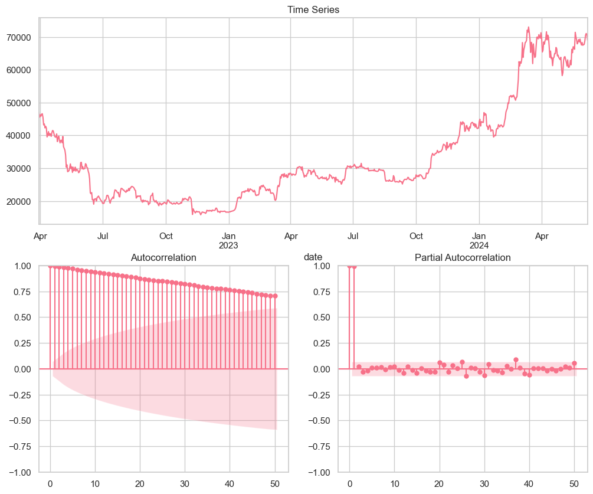

```python
plotds(BTC_USD_df.close)
```

Para nuestra BTC le asignamos un p de 1 porque es el mas optimo segun la literatura y un q de 0 por la autocorrelacion parcial.

```python
#BTC
n_train = len(BTC_USD_df.close); n_test = 28
train_size = n_train - n_test

train_BTC = BTC_USD_df.close[:train_size]
dates_train = BTC_USD_df.index[:train_size]
test_4w_BTC = BTC_USD_df.close[train_size:train_size + n_test]
dates_4w = BTC_USD_df.index[train_size:train_size + n_test]
```

```python
from statsmodels.tsa.arima.model import ARIMA


def arima_rolling(history, test):

    predictions = list()
    for t in range(len(test)):
        model = ARIMA(history, order=(1,1,0))
        model_fit = model.fit()
        output = model_fit.forecast()
        yhat = output[0]
        predictions.append(yhat)
        obs = test[t]
        history.append(obs)
        print('predicted=%f, expected=%f' % (yhat, obs))

    return predictions,model_fit

test_4wBTC = test_4w_BTC.tolist()
yhat_BTC,model_BTC  = arima_rolling(train_BTC.tolist(), test_4wBTC)
```

```
predicted=60982.939541, expected=60793.710938
predicted=60793.632547, expected=61448.394531
predicted=61393.412973, expected=62901.449219
predicted=62780.500907, expected=61552.789062
predicted=61666.761920, expected=66267.492188
predicted=65850.760684, expected=65231.582031
predicted=65325.281944, expected=67051.875000
predicted=66885.051781, expected=66940.804688
predicted=66950.979428, expected=66278.367188
predicted=66339.027791, expected=71448.195312
predicted=70966.424834, expected=70136.531250
predicted=70262.586023, expected=69122.335938
predicted=69218.771832, expected=67929.562500
predicted=68041.905851, expected=68526.101562
predicted=68469.668370, expected=69265.945312
predicted=69196.182688, expected=68518.093750
predicted=68588.878116, expected=69394.554688
predicted=69311.230107, expected=68296.218750
predicted=68401.297291, expected=67578.093750
predicted=67646.368464, expected=68364.992188
predicted=68289.892379, expected=67491.414062
predicted=67575.167427, expected=67706.937500
predicted=67686.250968, expected=67751.601562
predicted=67747.313591, expected=68804.781250
predicted=68703.705406, expected=70567.765625
predicted=70401.019163, expected=71082.820312
predicted=71034.511979, expected=70757.164062
predicted=70787.748694, expected=69057.031250
```

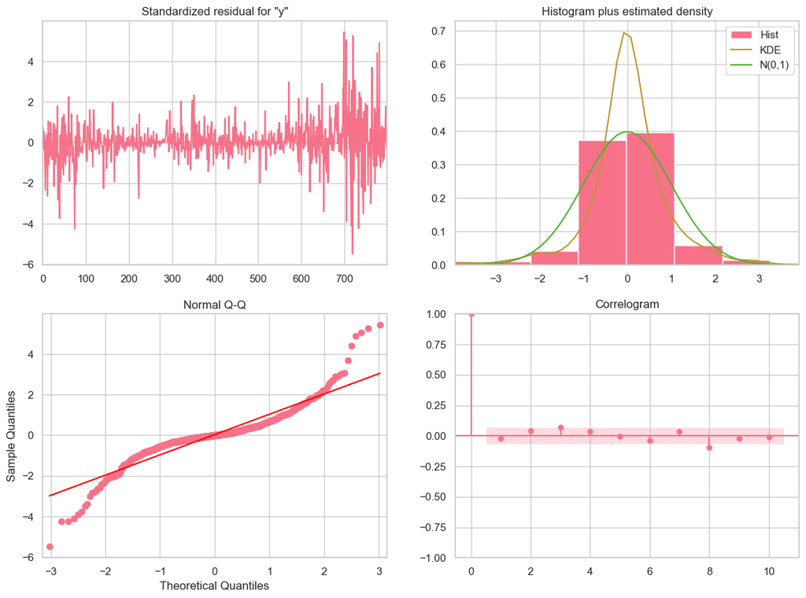

```python
model_BTC.plot_diagnostics(figsize=(14,10));
```

```python
def forecast_accuracy(forecast, actual,model, str_name):

    mape = np.mean(np.abs(forecast - actual)/np.abs(actual)) # MAPE
    mae = np.mean(np.abs(forecast - actual))                 # MAE
    rmse = np.mean((forecast - actual)**2)**.5               # RMSE
    mse = np.mean((forecast - actual)**2)                    # MSE
    df_acc = pd.DataFrame({'MAE': [mae],
                           'MSE': [mse],
                           'MAPE': [mape],
                           'RMSE': [rmse],
                          "AIC": [model.aic]},
                          index=[str_name])

    return df_acc
BTC=forecast_accuracy(np.array(test_4wBTC),np.array(yhat_BTC),model_BTC, "BTC")
BTC.head()
```

|  | MAE | MSE | MAPE | RMSE | AIC |
| --- | --- | --- | --- | --- | --- |
| BTC | 1126.828446 | 2.570655e+06 | 0.016995 | 1603.326112 | 13373.779532 |

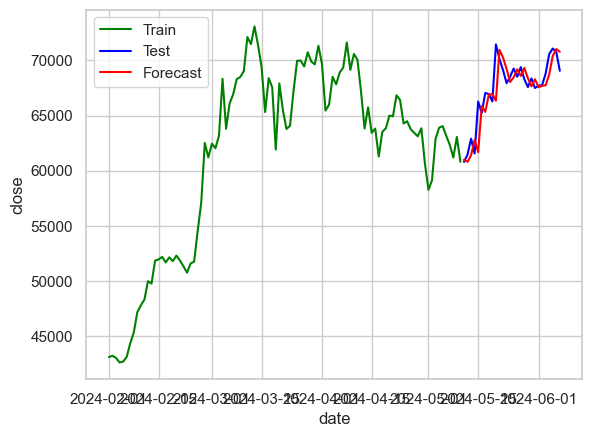

```python
ax = sns.lineplot(x=dates_train[-100:], y=train_BTC[-100:], label="Train", color='g')
sns.lineplot(x=dates_4w, y=test_4wBTC, label="Test", color='b')
sns.lineplot(x=dates_4w, y=yhat_BTC, label="Forecast", color='r')
plt.show()
```

## Sarimax

Es una extension de arima con un componente de season,tiene el los mismo parametros que **(p,d,q)** y **m** qu es el componente season.

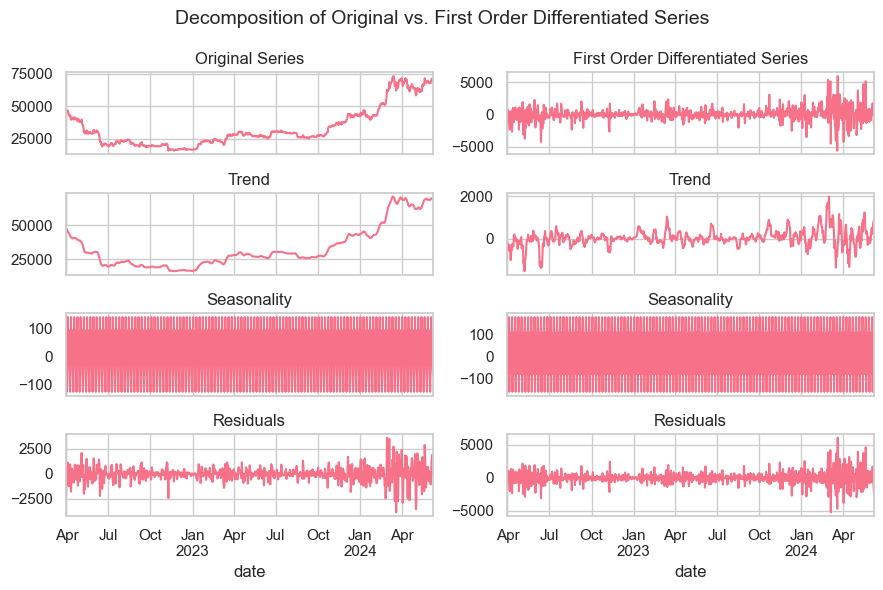

```python
# Decomposing the Original and First Order Differentiated Series
res_decompose = seasonal_decompose(BTC_USD_df["close"], model='additive', extrapolate_trend='freq')
res_decompose_diff_1 = seasonal_decompose(BTC_USD_df["diff"], model='additive', extrapolate_trend='freq')

# Plotting the Decomposition Results
fig, axs = plt.subplots(nrows=4, ncols=2, figsize=(9, 6), sharex=True)

# Original Series Decomposition
res_decompose.observed.plot(ax=axs[0, 0])
axs[0, 0].set_title('Original Series')
res_decompose.trend.plot(ax=axs[1, 0])
axs[1, 0].set_title('Trend')
res_decompose.seasonal.plot(ax=axs[2, 0])
axs[2, 0].set_title('Seasonality')
res_decompose.resid.plot(ax=axs[3, 0])
axs[3, 0].set_title('Residuals')

# First Order Differentiated Series Decomposition
res_decompose_diff_1.observed.plot(ax=axs[0, 1])
axs[0, 1].set_title('First Order Differentiated Series')
res_decompose_diff_1.trend.plot(ax=axs[1, 1])
axs[1, 1].set_title('Trend')
res_decompose_diff_1.seasonal.plot(ax=axs[2, 1])
axs[2, 1].set_title('Seasonality')
res_decompose_diff_1.resid.plot(ax=axs[3, 1])
axs[3, 1].set_title('Residuals')

fig.suptitle('Decomposition of Original vs. First Order Differentiated Series', fontsize=14)
fig.tight_layout();
```

```python
from statsmodels.tsa.arima.model import ARIMA


def sarima_rolling(history, test):

    predictions = list()
    for t in range(len(test)):
        model = ARIMA(history,order=(1, 1, 0), seasonal_order=(1, 1, 0, 12))
        model_fit = model.fit()
        output = model_fit.forecast()
        yhat = output[0]
        predictions.append(yhat)
        obs = test[t]
        history.append(obs)
        print('predicted=%f, expected=%f' % (yhat, obs))

    return predictions, model
test_4wBTC = test_4w_BTC.tolist()
yhat_BTC,smodel_BTC  = sarima_rolling(train_BTC.tolist(), test_4wBTC)
```

```
predicted=60647.945140, expected=60793.710938
predicted=59443.979903, expected=61448.394531
predicted=59788.087115, expected=62901.449219
predicted=63528.630970, expected=61552.789062
predicted=64236.244961, expected=66267.492188
predicted=67301.906559, expected=65231.582031
predicted=65471.826142, expected=67051.875000
predicted=65492.747305, expected=66940.804688
predicted=66322.554299, expected=66278.367188
predicted=65305.169464, expected=71448.195312
predicted=71745.098781, expected=70136.531250
predicted=68888.595150, expected=69122.335938
predicted=69305.014159, expected=67929.562500
predicted=67420.919753, expected=68526.101562
predicted=68458.486913, expected=69265.945312
predicted=68607.590573, expected=68518.093750
predicted=72924.966376, expected=69394.554688
predicted=69543.001100, expected=68296.218750
predicted=69632.679897, expected=67578.093750
predicted=67458.237510, expected=68364.992188
predicted=67491.181158, expected=67491.414062
predicted=70474.420446, expected=67706.937500
predicted=67880.818293, expected=67751.601562
predicted=66265.645043, expected=68804.781250
predicted=67704.983980, expected=70567.765625
predicted=70861.826232, expected=71082.820312
predicted=72088.779690, expected=70757.164062
predicted=69964.041051, expected=69057.031250
```

```python
def forecast_accuracy(forecast, actual,model, str_name):

    mape = np.mean(np.abs(forecast - actual)/np.abs(actual)) # MAPE
    mae = np.mean(np.abs(forecast - actual))                 # MAE
    rmse = np.mean((forecast - actual)**2)**.5               # RMSE
    mse = np.mean((forecast - actual)**2)                    # MSE
    df_acc = pd.DataFrame({'MAE': [mae],
                           'MSE': [mse],
                           'MAPE': [mape],
                           'RMSE': [rmse]},
                          index=[str_name])

    return df_acc
BTCs=forecast_accuracy(np.array(test_4wBTC),np.array(yhat_BTC),smodel_BTC, "Sarima BTC")
BTCs.head()
```

|  | MAE | MSE | MAPE | RMSE |
| --- | --- | --- | --- | --- |
| Sarima BTC | 1581.1849 | 4.243592e+06 | 0.023694 | 2059.997981 |

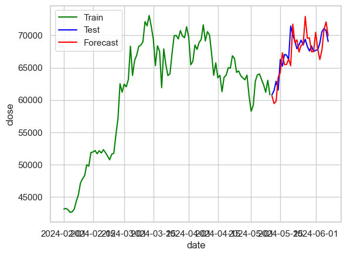

```python
ax = sns.lineplot(x=dates_train[-100:], y=train_BTC[-100:], label="Train", color='g')
sns.lineplot(x=dates_4w, y=test_4wBTC, label="Test", color='b')
sns.lineplot(x=dates_4w, y=yhat_BTC, label="Forecast", color='r')
plt.show()
```

```python
def sarima_rolling4 (history, test):

    predictions = list()
    for t in range(len(test)):
        model = ARIMA(history,order=(1, 1, 0), seasonal_order=(1, 1, 0, 4))
        model_fit = model.fit()
        output = model_fit.forecast()
        yhat = output[0]
        predictions.append(yhat)
        obs = test[t]
        history.append(obs)
        print('predicted=%f, expected=%f' % (yhat, obs))

    return predictions, model
test_4wBTC = test_4w_BTC.tolist()
yhat_BTC,smodel_BTC  = sarima_rolling4(train_BTC.tolist(), test_4wBTC)
```

```
predicted=61423.969734, expected=60793.710938
predicted=60286.424734, expected=61448.394531
predicted=62717.254833, expected=62901.449219
predicted=61025.381124, expected=61552.789062
predicted=61273.678981, expected=66267.492188
predicted=65971.206906, expected=65231.582031
predicted=66909.311827, expected=67051.875000
predicted=65427.109175, expected=66940.804688
predicted=70209.614007, expected=66278.367188
predicted=66109.733259, expected=71448.195312
predicted=72568.234873, expected=70136.531250
predicted=70025.050766, expected=69122.335938
predicted=69995.696586, expected=67929.562500
predicted=71588.918444, expected=68526.101562
predicted=68382.031266, expected=69265.945312
predicted=68374.525920, expected=68518.093750
predicted=67470.371008, expected=69394.554688
predicted=71052.724635, expected=68296.218750
predicted=68793.276270, expected=67578.093750
predicted=66851.943199, expected=68364.992188
predicted=68475.839453, expected=67491.414062
predicted=67004.957151, expected=67706.937500
predicted=67309.534965, expected=67751.601562
predicted=68062.388331, expected=68804.781250
predicted=68349.816587, expected=70567.765625
predicted=70169.617162, expected=71082.820312
predicted=70835.260712, expected=70757.164062
predicted=71751.233068, expected=69057.031250
```

```python
BTCs=forecast_accuracy(np.array(test_4wBTC),np.array(yhat_BTC),smodel_BTC, "Sarima BTC")
BTCs.head()
```

|  | MAE | MSE | MAPE | RMSE |
| --- | --- | --- | --- | --- |
| Sarima BTC | 1601.33303 | 4.474401e+06 | 0.023701 | 2115.277948 |

La prediccion no cambia el procentaje de prediccion cuando se cambia de annual por trimestral lo que nos quedamos con el modelo arima con roling. Esto se debe a que debido al crecimiento de los ultimos años los ultimos meses tengan mas tiempo.